# Calidad de la declaración de edad en Chiapas

Censo de Población y Vivienda 2020

Manuel Razo Alcántara

# 1 Objetivo

En un censo, la edad se declara de memoria y muchas veces la responde otra persona del hogar. Por eso suele concentrarse en edades “redondas”, terminadas en 0 o en 5. Antes de usar la estructura por edad de una población, conviene medir qué tan confiable es esa declaración.

En este reporte evalúo la calidad de la declaración de edad en Chiapas con datos del Censo 2020. Uso tres índices (Whipple, Myers y Naciones Unidas) y después corrijo la población por grupos de edad: reparto la edad no especificada y suavizo los grupos quinquenales.

# 2 Datos

La fuente es el Censo de Población y Vivienda 2020 del INEGI (cuestionario básico), con la población de Chiapas por sexo y por edad, tanto en años cumplidos como en grupos quinquenales. El censo registró **5,543,828 personas** en Chiapas, y **27,844** (0.50%) no declararon su edad.

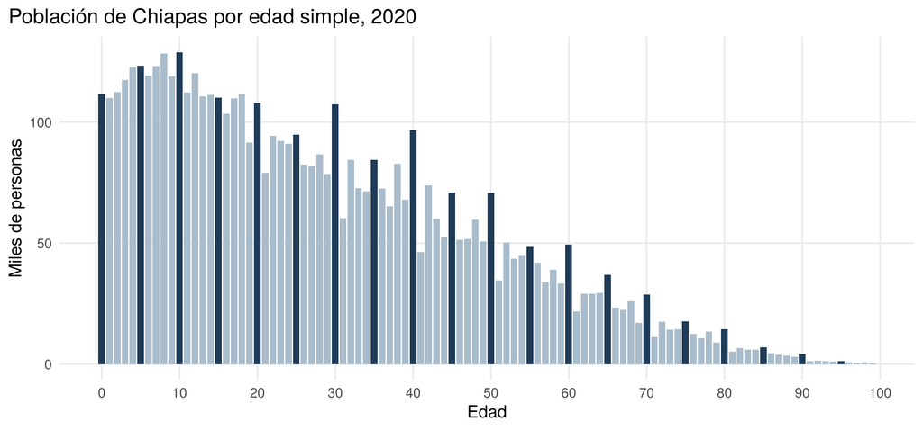

Población por edad simple. Las barras oscuras son las edades terminadas en 0 o en 5.

```r
edad_simple <- desplegadas |>
  filter(!is.na(edad_inicial), edad_inicial <= 99) |>
  mutate(redonda = edad_inicial %% 5 == 0)

g_edad <- ggplot(edad_simple, aes(edad_inicial, total / 1000, fill = redonda)) +
  geom_col(width = 0.85) +
  scale_fill_manual(values = c(`TRUE` = "#1F3B57", `FALSE` = "#A9BCCB"), guide = "none") +
  scale_x_continuous(breaks = seq(0, 100, 10)) +
  labs(x = "Edad", y = "Miles de personas",
       title = "Población de Chiapas por edad simple, 2020") +
  tema
g_edad
```

Los picos en 20, 30, 40, 50 y 60 años, y en menor medida en las edades terminadas en 5, ya muestran la preferencia por ciertos dígitos. Los índices siguientes la miden.

# 3 Índice de Whipple

El índice de Whipple compara la población con edades terminadas en 0 y 5 (o solo en 0) contra la que se esperaría si todos los dígitos tuvieran el mismo peso, en el rango de 23 a 62 años. Si no hubiera preferencia, valdría 100.

```r
whipple <- calcular_whipple(desplegadas)
write.csv(whipple, "salidas/whipple.csv", row.names = FALSE)

kable(whipple, digits = 2, format.args = list(big.mark = ","),
      col.names = c("Población", "Dígito evaluado", "Índice de Whipple", "Clasificación"))
```

| Población | Dígito evaluado | Índice de Whipple | Clasificación |
| --- | --- | --- | --- |
| Total | Terminación 0 y 5 | 123.04 | Datos aproximados |
| Total | Terminación 0 | 128.14 | Datos deficientes |
| Hombres | Terminación 0 y 5 | 124.28 | Datos aproximados |
| Hombres | Terminación 0 | 129.92 | Datos deficientes |
| Mujeres | Terminación 0 y 5 | 121.93 | Datos aproximados |
| Mujeres | Terminación 0 | 126.53 | Datos deficientes |

Para la población total, el índice es de **123.04** para las edades terminadas en 0 y 5, es decir, se declaran 23% más edades redondas de las esperadas, y los datos se clasifican como aproximados. Si se considera solo el dígito 0, el índice sube a **128.14** y los datos pasan a deficientes: la atracción hacia el 0 es más fuerte que hacia el 5. Los hombres tienen índices un poco más altos que las mujeres.

# 4 Índice de Myers

El índice de Myers revisa los diez dígitos finales, no solo el 0 y el 5. Para cada dígito calcula qué porcentaje de la población declara una edad que termina en él (entre 10 y 79 años) y lo compara con el 10% esperado. El índice es la suma de esas desviaciones: va de 0 (sin preferencia) a 180 (todas las edades terminan en el mismo dígito).

```r
myers <- calcular_myers(desplegadas)
write.csv(myers$resumen, "salidas/myers_resumen.csv", row.names = FALSE)
write.csv(myers$tablas$total, "salidas/myers_detalle_total.csv", row.names = FALSE)

kable(myers$resumen, digits = 3,
      col.names = c("Población", "Índice de Myers", "Clasificación"))
```

| Población | Índice de Myers | Clasificación |
| --- | --- | --- |
| Total | 10.384 | Mediana concentración en algún dígito |
| Hombres | 10.791 | Mediana concentración en algún dígito |
| Mujeres | 10.009 | Mediana concentración en algún dígito |

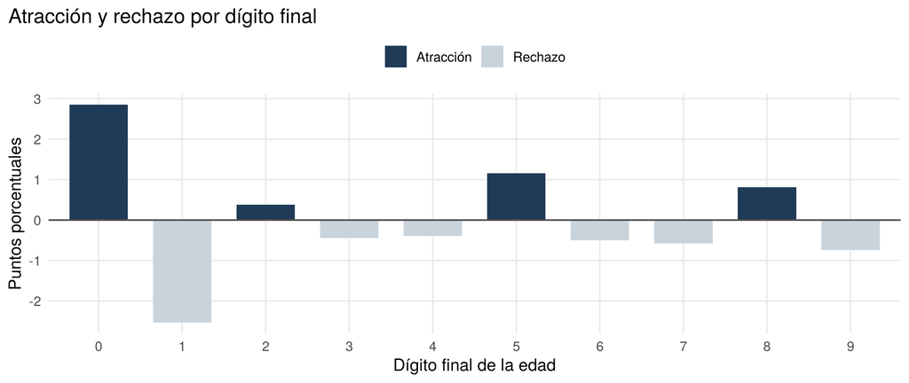

Desviación de cada dígito final respecto al 10% esperado, población total.

```r
detalle <- myers$tablas$total
g_myers <- ggplot(detalle, aes(factor(digito), Mj, fill = atraccion_rechazo)) +
  geom_col(width = 0.7) +
  geom_hline(yintercept = 0, color = "grey30") +
  scale_fill_manual(values = c(`Atracción` = "#1F3B57", Rechazo = "#C9D3DB"), name = NULL) +
  labs(x = "Dígito final de la edad", y = "Puntos porcentuales",
       title = "Atracción y rechazo por dígito final") +
  tema + theme(legend.position = "top")
g_myers
```

El índice de Myers para la población total es de **10.38**, una concentración mediana. Los dígitos 0, 2, 5 y 8 atraen declaraciones y los dígitos 1, 3, 4, 6, 7 y 9 las rechazan. El que más atrae es el **0** y el que más rechaza es el **1**, lo que confirma lo que se veía en la gráfica de edades simples. El patrón es el mismo para hombres y mujeres.

# 5 Índice de Naciones Unidas

El Índice de Naciones Unidas trabaja con grupos quinquenales. Combina tres medidas de irregularidad entre grupos vecinos: el cociente de edades de hombres (IEH), el de mujeres (IEM) y el cambio en el índice de masculinidad (IRS), con la fórmula INU = IEH + IEM + 3 × IRS. Se usan los grupos de 0-4 a 80-84 años.

```r
inu <- calcular_inu(quinquenales)
write.csv(inu$tabla, "salidas/inu_detalle.csv", row.names = FALSE)

kable(inu$resumen, digits = 3,
      col.names = c("IEH", "IEM", "IRS", "INU", "Clasificación"))
```

| IEH | IEM | IRS | INU | Clasificación |
| --- | --- | --- | --- | --- |
| 2.644 | 2.249 | 2.084 | 11.146 | Información satisfactoria |

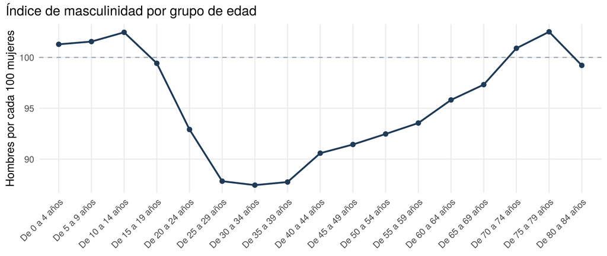

Índice de masculinidad por grupo quinquenal.

```r
inu_tabla <- inu$tabla |> mutate(grupo_edad = factor(grupo_edad, levels = grupo_edad))
ggplot(inu_tabla, aes(grupo_edad, indice_masculinidad, group = 1)) +
  geom_hline(yintercept = 100, linetype = "dashed", color = col_neutro) +
  geom_line(color = "#1F3B57", linewidth = 0.9) +
  geom_point(color = "#1F3B57", size = 2) +
  labs(x = NULL, y = "Hombres por cada 100 mujeres",
       title = "Índice de masculinidad por grupo de edad") +
  tema + theme(axis.text.x = element_text(angle = 45, hjust = 1))
```

El INU es de **11.15**, menor que 20, así que la información por grupos quinquenales es **satisfactoria**. Al agrupar en quinquenios, buena parte de la atracción hacia el 0 y el 5 queda dentro del mismo grupo y deja de pesar. Lo que más aporta al índice es la irregularidad del índice de masculinidad: baja de 102 a 87 hombres por cada 100 mujeres entre los 10 y los 34 años, algo que suele asociarse con la migración de hombres jóvenes y con su menor cobertura en el censo.

# 6 Prorrateo y suavizamiento

Para trabajar con la estructura por edad, primero reparto a las 27,844 personas sin edad declarada entre los 18 grupos quinquenales, en proporción al tamaño de cada uno. Después suavizo los grupos de 10-14 a 70-74 años con el promedio móvil de 1/16 y reescalo el resultado para conservar el total.

```r
prorrateo <- calcular_prorrateo(quinquenales)
write.csv(prorrateo, "salidas/prorrateo_suavizamiento.csv", row.names = FALSE)

prorrateo |>
  select(grupo_edad, total_original, total_prorrateado, total_suavizado, total_ajustado) |>
  bind_rows(summarise(prorrateo, grupo_edad = "Total",
                      across(c(total_original, total_prorrateado, total_suavizado, total_ajustado), sum))) |>
  kable(format.args = list(big.mark = ","),
        col.names = c("Grupo de edad", "Original", "Prorrateado", "Suavizado 1/16", "Ajustado"))
```

| Grupo de edad | Original | Prorrateado | Suavizado 1/16 | Ajustado |
| --- | --- | --- | --- | --- |
| De 0 a 4 años | 574,152 | 577,050 | 577,050 | 576,652 |
| De 5 a 9 años | 612,792 | 615,885 | 615,885 | 615,460 |
| De 10 a 14 años | 583,132 | 586,076 | 587,333 | 586,928 |
| De 15 a 19 años | 526,577 | 529,235 | 528,856 | 528,491 |
| De 20 a 24 años | 464,523 | 466,868 | 469,230 | 468,906 |
| De 25 a 29 años | 424,403 | 426,545 | 426,320 | 426,026 |
| De 30 a 34 años | 396,045 | 398,044 | 399,242 | 398,967 |
| De 35 a 39 años | 372,863 | 374,745 | 371,924 | 371,667 |
| De 40 a 44 años | 329,204 | 330,866 | 331,725 | 331,496 |
| De 45 a 49 años | 284,333 | 285,768 | 286,836 | 286,638 |
| De 50 a 54 años | 243,848 | 245,079 | 243,304 | 243,136 |
| De 55 a 59 años | 196,355 | 197,346 | 198,732 | 198,595 |
| De 60 a 64 años | 158,726 | 159,527 | 159,934 | 159,824 |
| De 65 a 69 años | 125,777 | 126,412 | 124,160 | 124,074 |
| De 70 a 74 años | 85,855 | 86,288 | 89,030 | 88,969 |
| De 75 a 79 años | 63,158 | 63,477 | 63,477 | 63,433 |
| De 80 a 84 años | 38,245 | 38,438 | 38,438 | 38,411 |
| 85 años y más | 35,996 | 36,178 | 36,178 | 36,153 |
| Total | 5,515,984 | 5,543,827 | 5,547,654 | 5,543,826 |

La tabla muestra la población total; el archivo `salidas/prorrateo_suavizamiento.csv` incluye también hombres y mujeres.

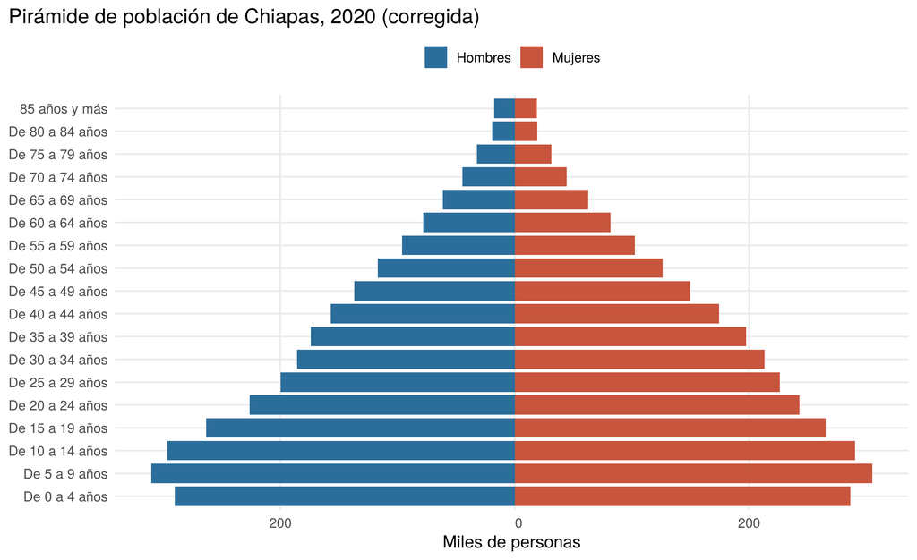

Pirámide de población con los grupos prorrateados y suavizados.

```r
piramide <- prorrateo |>
  transmute(grupo_edad = factor(grupo_edad, levels = grupo_edad),
            Hombres = -hombres_ajustado / 1000, Mujeres = mujeres_ajustado / 1000) |>
  pivot_longer(c(Hombres, Mujeres), names_to = "sexo", values_to = "miles")

g_piramide <- ggplot(piramide, aes(miles, grupo_edad, fill = sexo)) +
  geom_col(width = 0.85) +
  scale_x_continuous(labels = function(x) format(abs(x), big.mark = ",")) +
  scale_fill_manual(values = c(Hombres = col_hombres, Mujeres = col_mujeres), name = NULL) +
  labs(x = "Miles de personas", y = NULL,
       title = "Pirámide de población de Chiapas, 2020 (corregida)") +
  tema + theme(legend.position = "top")
g_piramide
```

# 7 Conclusiones

- La declaración por edad simple en Chiapas tiene una preferencia clara por las edades terminadas en 0 y, en menor medida, en 5. El índice de Whipple la clasifica como aproximada (0 y 5) o deficiente (solo 0), y el de Myers como de concentración mediana.
- Por grupos quinquenales la calidad es satisfactoria según el Índice de Naciones Unidas, así que los quinquenios son una base razonable para análisis demográficos del estado.
- Antes de usar edades simples conviene corregirlas. Con los quinquenios basta repartir la edad no especificada y suavizar, como se hizo aquí.
- Las funciones de `R/funciones_demografia.R` reciben cualquier estado y año con el mismo formato de datos, así que el análisis se puede repetir para otras entidades sin cambiar el código.